# Change in community phylogenetic structure during tropical forest succession: evidence from New Guinea - Whitfeld - 2012 - Ecography - Wiley Online Library

[Ecography](https://onlinelibrary.wiley.com/journal/16000587)

[Volume 35, Issue 9](https://onlinelibrary.wiley.com/toc/16000587/2012/35/9)

[figure not shown]

Free Access

# Change in community phylogenetic structure during tropical forest succession: evidence from New Guinea

[T. J. S. Whitfeld](https://onlinelibrary.wiley.com/action/doSearch?ContribAuthorStored=Whitfeld%2C+T+J+S)

[W. J. Kress](https://onlinelibrary.wiley.com/action/doSearch?ContribAuthorStored=Kress%2C+W+J)

[D. L. Erickson](https://onlinelibrary.wiley.com/action/doSearch?ContribAuthorStored=Erickson%2C+D+L)

[G. D. Weiblen](https://onlinelibrary.wiley.com/action/doSearch?ContribAuthorStored=Weiblen%2C+G+D)

First published: 28 November 2011

https://doi.org/10.1111/j.1600-0587.2011.07181.x

Citations: 63

T. J. S. Whitfeld, Univ. of Minnesota, Dept of Forest Resources, 115 Green Hall, 1530 Cleveland Ave. N., St Paul, MN 55108–1095, USA. E‐mail: whitf015@umn.edu

## Abstract

Ecologists have recently interpreted patterns of phylogenetic distance among coexisting species as indicative of processes affecting community assembly during forest succession. We investigated plant community phylogenetic structure along a successional gradient in New Guinean lowland rain forest. We surveyed all trees with diameter at breast height ≥ 5 cm in nineteen 0.25 ha plots representing younger secondary, older secondary, and primary forest. We estimated plant community phylogeny from rbcL gene sequences to quantify change in phylogenetic structure during succession. Mean phylogenetic distance among co‐occurring trees increased with total basal area per plot, a proxy for forest age. Significant phylogenetic clustering was detected in secondary forest whereas primary forest was significantly over‐dispersed relative to null expectations. We examined the sensitivity of these patterns to various methods of branch length estimation and phylogenetic uncertainty. Power to detect community phylogenetic patterns when equal branch lengths were assumed was weak in comparison to direct molecular and time‐calibrated measures of divergence. Inferred change during forest succession was also robust to phylogenetic uncertainty so long as temporal information was incorporated in estimates of divergence. The observed patterns are consistent with processes of environmental filtering during tropical forest succession giving way to other processes in primary forests including density‐dependence.

Tropical rain forests are the most productive and biologically diverse terrestrial ecosystems (Leigh 1999). They cover < 10% of the Earth's land surface yet contain close to half of all species. A fundamental question for ecologists concerns mechanisms of species coexistence, particularly at small spatial scales in diverse forests (Wright 2002). For example, one‐hectare plots in lowland rain forest can contain several hundred tree species (Proctor et al. 1983, Leigh 1999) whereas in most temperate regions a similar sized plot would include < 20 species (Burnham et al. 1992, Leigh 1999). The concept of limiting similarity makes the high diversity in tropical areas hard to explain. This idea was based on experiments demonstrating that laboratory communities could not coexist over the long term when resources were limited (Gause 1934). Gause's experiments verified the theoretical prediction that became known as the competitive exclusion principle (Hardin 1960). This tenet also led to the idea that a species could not become part of a community without the counteracting loss of another and that ‘rules’ govern the assembly of communities (Diamond 1975).

Approaches to understanding the assembly and main tenance of diverse communities combine a regional historical perspective (Ricklefs 1987) with an emphasis on the ecological niche (Diamond 1975). In this framework, local community diversity is a reflection of regional availability (Ricklefs 1987, McPeek and Brown 2000), environmental filters that restrict membership of a community to species possessing the necessary phenotypes, and local interactions affecting survival (Diamond 1975, Bazzaz 1991, Weiher and Keddy 1995, Webb 2000, HilleRisLambers et al. 2002, Wright 2002, Cavender‐Bares 2004a, b, Svenning et al. 2008). Alternatively, neutral theory (Hubbell 2001) assumes that species are competitive equivalents with the same prospects for survival and reproduction. In this situation, functional differences between species are unimportant and communities are the result of processes such as dispersal, speciation, and extinction with ecological processes such as competition playing a limited role (Hubbell 2001).

A phylogenetic perspective that recognizes the dual role of evolutionary history in generating species diversity and in shaping phenotypes may provide insight into the relative importance of different processes affecting species coexistence and community assembly (Webb et al. 2002). Phylogenetic community ecology attempts to connect the evolutionary history of coexisting organisms with ecological mechanisms driving patterns of distribution and abundance (Kraft et al. 2007, Cavender‐Bares et al. 2009).

Estimates of community phylogeny have been used to test assembly hypotheses related to ecological processes such as environmental filtering and competition (Webb et al. 2002). Environmental filters can restrict long‐term community membership to those individuals that possess phenotypes necessary for survival and successful reproduction (Weiher and Keddy 1995, Webb 2000, Webb et al. 2002) resulting in a community of species that share a closer evolutionary history than would be expected by chance (phylogenetic clustering). By contrast, competition theory (Svenning et al. 2008) predicts that closely related species with similar phenotypes are more likely to compete directly with each other and less likely to coexist. A community comprised of species more distantly related than expected by chance (phylogenetic over‐dispersion) may signal competitive exclusion if we assume niche conservatism (Ackerly 2004). However, traits influencing community membership can also be convergent (Cavender‐Bares et al. 2006) such that the assumption of niche conservatism is not always appropriate (Swenson and Enquist 2009). Other community ecological processes further complicate the interpretation of community phylogenetic patterns. Trophic interactions are predicted to have negative density‐dependent effects impacting the distribution of diversity such that recruitment of species in proximity to close relatives can be limited by specialized pests and pathogens (Gilbert and Webb 2007) which tend to yield patterns of over‐dispersion (Wills et al. 2006, Comita et al. 2010). Mutualism and facilitation might produce patterns of clustering by promoting benefits to close relatives through mechanisms such as shared pollinators (Sargent and Ackerly 2008) or over‐dispersion where positive interactions occur between distant relatives. The latter has been noted where ‘nurse plants’ facilitate protected microhabitats for the germination and establishment of distant relatives (Valiente‐Banuet and Verdu 2007).

Each of the aforementioned processes has been invoked to account for patterns of diversity in the tropics that also happen to be the ancestral home of many flowering plant lineages. The challenge of explaining elevated tropical plant diversity has made the region a particular target for community phylogenetic analysis (Webb 2000, Kembel and Hubbell 2006, Kress et al. 2009, Gonzalez et al. 2010, Letcher 2010). The island of New Guinea, although recognized for high biological diversity, endemism, and the world's third largest undisturbed tropical forest after the Amazon and Congo basins has, however, not been the subject of a community phylogenetic study. We investigated New Guinea lowland rain forest succession and expanded upon similar investigations (Letcher 2010) by applying DNA sequences to estimate phylogenetic branch lengths directly. Studies using DNA sequences for direct community phylogeny estimation have not investigated forest succession (Kress et al. 2009) even as secondary forest has become a predominant feature of tropical landscapes.

Empirical studies and forest succession theory predict changes in abiotic conditions during succession (Oliver and Larson 1990, Lebrija‐Trejos et al. 2010). Phylogenetic niche‐conservatism assumes that ecologically similar species are likely to be closely related such that the homogenous conditions of early succession are expected to support a phylogenetically clustered community whereas the heterogeneous abiotic conditions of primary forest, along with perhaps other processes such as competitive exclusion and density‐dependent mortality, favors primary forest over‐dispersion. We tested the prediction that the overall community phylogenetic pattern shifts from that of clustering to over‐dispersion during ecological succession using basal area as a proxy for forest age.

## Methods

### Survey plots

A total forest area of 4.75 ha was surveyed near Wanang (145°5′32″E, 5°14′26″S), Madang Province, Papua New Guinea. The field site is in a mosaic of primary and secondary rainforest vegetation at 100–200 m a.s.l. It is part of an extensive mixed evergreen forest on latosols in the Ramu River basin. The region is characterized by a humid climate with mean annual rainfall of 3500 mm, a mild dry season from July to September, and mean monthly temperature of 26°C (McAlpine et al. 1983). Sampling included nineteen 0.25 ha plots (50 by 50 m). Five plots were located in younger secondary forest (< 10 yr since disturbance), seven plots in older secondary forest (10–20 yr since disturbance), and seven plots in primary forest (> 50 yr since disturbance). Plots were not randomly located but were rather based on the distribution of abandoned subsistence agricultural plots in the study area. Approximate ages were obtained through interviews with landowners. A minimum age for primary forest in the area was estimated from Royal Australian Survey Corps aerial photographs, where the presence of multi‐layered canopy in 1973 suggests no anthropogenic disturbance since at least the late 1950s. Local landowners practice subsistence agriculture in 0.25–1.0 ha gardens planted after felling and burning of primary forest. Succession ensues when garden plots are abandoned after 2–3 yr of low intensity cultivation.

### Species identification

Trees with diameter at breast height (dbh) ≥ 5 cm were measured, tagged, and identified to estimate species abundance (based on the number of individual stems per species) and diversity for each plot. Following preliminary field identification by foresters, vouchers were collected and verified at the Papua New Guinea Forest Research Inst., Lae herbarium (LAE). Complete sets of vouchers were deposited at LAE and the Herbarium of the J. F. Bell Museum of Natural History at the Univ. of Minnesota (MIN) with additional material distributed to herbaria including A, US, K, L, CANB, SING, F, NY, and MO.

### Phylogenetic analysis

We estimated phylogenetic relationships among all species of woody plants including trees, shrubs, and vines ≥ 5 cm dbh that occurred in the sample plots. A neighbor‐joining tree of 860 rbcL sequences representing 349 species and up to four samples per species was obtained using PAUP* ver. 4 (Swofford 2001) and resolved the monophyly of most orders and families. Sequences that appeared out of position relative to expected placement within orders and families prompted re‐examination and re‐sequencing of voucher specimens that, in five cases, corrected field misidentifications. Taxon sampling and sequence variation in rbcL was insufficient to evaluate species monophyly with confidence. The dataset was pruned to include a single sequence per species for the purpose of Bayesian phylogenetic analysis (see also Sensitivity analysis). A general time‐reversible model of molecular evolution with parameters for invariant sites and rate heterogeneity among sites (GTR +Γ+ I) was selected for the pruned 349‐taxon dataset using the Akaike information criterion.

Bayesian analysis was conducted using BEAST (Drummond and Rambaut 2007) under GTR +Γ+ I so that phylogenetic relationships and divergence times could be estimated simultaneously. We assumed a relaxed molecular clock considering that rbcL strongly rejected a strict clock according to the likelihood‐ratio test (χ²= 688, DF = 347, p < 0.001). Topological constraints were enforced to incorporate prior knowledge of well‐supported relationships while allowing unresolved relationships to be estimated from sequence variation in the community sample (Kress et al. 2010). Constraints included the monophyly of Angiosperm Phylogeny Group (APG 2009) orders and families and well‐supported relationships as indicated in the Supplementary material (Appendix 1, Fig. A1–A6). Support for these phylogenetic hypotheses is far more extensive than what can be expected from community barcodes and it is desirable to incorporate this prior information while resolving the remaining relationships with DNA sequences from community members. We further assessed the sensitivity of results to uncertainty associated with this approach (see Sensitivity analysis).

Information on the minimum ages of major angiosperm lineages was incorporated in the Bayesian analysis by setting node age priors in BEAST. Thirty‐one nodes were identified using Phylomatic (<www.phylodiversity.net/phylomatic/phylomatic.html>). We applied these as node age priors in Bayesian analysis along with rbcL sequences, model parameters, and topological constraints as described above. A Markov‐chain Monte Carlo simulation of 10 million generations was sampled every 1000 generations and the first 1000 trees were discarded as burn‐in. Among the posterior distribution of 9000 trees, the topology with the highest likelihood was used to quantify community phylogenetic patterns.

### Community phylogeny metrics

Mean pair‐wise phylogenetic distance (MPD) and mean nearest taxon phylogenetic distance (MNTD) among individuals occurring in each survey plot were calculated using the Picante package (Kembel et al. 2010). These metrics describe different components of phylogenetic diversity. By taking into account all pair‐wise distances in a sample of taxa, MPD provides an overall measure of phylogenetic diversity whereas MNTD, in quantifying distances between nearest neighbors, describes the degree to which community members are terminally clustered (Webb 2000). Null models were used to compare these community phylogenetic distance metrics to expectations of neutral theory (Hubbell 2001). The independent swap algorithm (Gotelli and Entsminger 2003) was used to randomize patterns of species co‐occurrence while maintaining per‐plot species richness and the frequency of species occurrence among plots. These assumptions are known to minimize type I error (Kembel and Hubbell 2006). The procedure further assumes that species may freely disperse among plots in a few generations and that the probability of colonization is proportional to the frequency of species occurrence among plots. These assumptions are reasonable given the proximity of our plots in a contiguous forest area.

The independent swap algorithm generates matrices composed of plots by species abundance and searches for “checkerboard” patterns (Diamond 1975). Such patterns consist of (0,n) and (n,0) or (n,0) and (0,n) where *n* and 0 represent the abundance and the absence of a particular species in two plots, respectively. When such patterns are encountered, the species abundance n and its absence are swapped between the plots. Abundance‐weighted swapping is comparable to the 3x null model of Hardy (2008) and is interpreted in terms of phylogenetic structure among individuals rather than among species (Kembel et al. 2010).

### Sensitivity analysis

We investigated the sensitivity of pattern detection to sources of error in phylogeny estimation including phylogenetic uncertainty and phylogenetic branch length assumptions. In the absence of information about evolutionary rates or divergence times, phylogenetic distance is sometimes approximated by the number of nodes separating any two taxa in a phylogeny. A popular improvement on this assumption is to incorporate minimum age estimates available for higher taxa and to evenly space the ages of intervening nodes such that branch length variance between dated nodes is minimal (Webb et al. 2008). Other approaches directly estimate genetic divergence of DNA sequences obtained from community members (Kress et al. 2009, Pei et al. 2011) or integrate such data with minimum age estimates using relaxed molecular clock assumptions as we did (Drummond and Rambaut 2007). Kress et al. (2009) advocated the use of DNA sequences over approximations of divergence times (Kembel and Hubbell 2006, Letcher 2010) or equal branch lengths (Webb 2000). We compared these assumptions using the same topology to examine their influence on the inference of community phylogenetic patterns.

Branch lengths were estimated by four different methods on the Bayesian topology described in Phylogenetic analysis. First, we applied an equal branch length assumption (EBL) using the “compute.brlen” command in Picante (Kembel et al. 2010). Second, branch lengths proportional to genetic distance (ML) were obtained by estimating in PAUP* ver. 4 (Swofford 2001) the likelihood of observing the rbcL sequence data under GTR +Γ+ I. Third, branch lengths were adjusted according to 31 minimum age estimates for major clades as implemented in Phylocom (Webb et al. 2008). The branch length adjustment algorithm (BLADJ) assigned branch lengths in millions of years to 31 dated nodes and evenly spaced the remaining nodes. Fourth, a relaxed mole cular clock Bayesian estimate integrating rbcL divergence and the aforementioned minimum age estimates for major clades as described in Phylogenetic analysis.

Even as systematic knowledge improves, evolutionary relationships among at least some members of most communities are likely to remain uncertain and community phylogenetic distance metrics could potentially be affected. Recent simulations (Swenson 2009) indicated that detection of community phylogenetic structure need not be strongly influenced by terminal phylogenetic resolution (e.g. relationships among congeners). We investigated the impact of phylogenetic uncertainty on power to detect clustering and over‐dispersion by comparing the significance of patterns inferred from the Bayes topology to those drawn from 100 randomly resolved constraint trees. This approach permuted relationships that were inferred from the rbcL sequences of community members while maintaining relationships strongly supported by independent evidence (as described in Phylogenetic analysis). We also investigated whether clustering and over‐dispersion were sensitive to the choice of topo logy from the Bayesian posterior distribution.

## Results

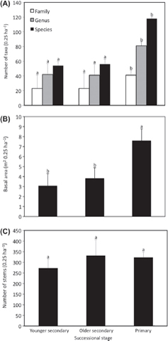

**Figure 1**

New Guinea lowland rain forest composition and structure in nineteen 0.25 ha plots representing younger secondary (n = 5), older secondary forest (n = 7), and primary forest (n = 7). (A) Taxonomic composition, (B) mean basal area 0.25 ha<sup>−1</sup>, and (C) mean stems with dbh ≥ 5 cm. Error bars represent one standard deviation. Bars with different letters were significantly different based on ANOVA (p < 0.05).

Bayesian analysis of rbcL sequences from the 349 woody plant species recorded in 19 survey plots yielded > 95% posterior probability for most community phylogenetic relationships (Supplementary material Appendix 1, Fig. A1–A6). Besides 141 nodes that were constrained according to prior systematic knowledge, incorporating the primary plant DNA barcode resolved an additional 62 out of 208 nodes with > 95% posterior probability. This approach represents a substantial improvement over the 40% resolution provided by Phylomatic.

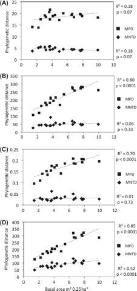

**Figure 2**

Mean phylogenetic distance of New Guinea woody plants (dbh ≥ 5 cm) from nineteen 0.25 ha plots with respect to basal area (m<sup>2</sup> 0.25 ha<sup>−1</sup>), a proxy for forest age. Per‐plot mean pair‐wise distance (MPD) and mean nearest taxon distance (MNTD) are depicted under four methods of branch length estimation and an identical topology. Assumptions included (A) equal branch lengths (EBL), (B) a maximum likelihood estimate of rbcL divergence (ML), (C) branch lengths adjusted with respect to minimum age estimates for major clades (BLADJ), and (D) an rbcL relaxed molecular clock Bayesian estimate calibrated by minimum age estimates for major clades (Bayes). Correlation coefficients (r<sup>2</sup>) and p‐values are indicated to the right of each linear regression.

Table 1. Phylogenetic distance in community samples of lowland New Guinea woody plants (dbh ≥ 5 cm) from nineteen 0.25 ha plots representing forests in three age classes. Per plot mean phylogenetic distance (MPD) and observed mean nearest taxon distance (MNTD) are compared among four different branch length assumptions. Phylogenetic distance was estimated under an identical topology and assumptions of 1) equal branch lengths (EBL), 2) a maximum likelihood estimate of rbcL divergence (ML), 3) branch lengths adjusted with respect to the minimum age estimates for major clades (BLADJ), and 4) an rbcL relaxed molecular clock Bayesian estimate calibrated by minimum age estimates for major clades (Bayes). N = number of species per plot. Significant departures from null expectations are indicated in bold type with ‡ indicating phylogenetic clustering and † indicating over‐dispersion.

| Forest age | N | MPD EBL | MPD ML | MPD BLADJ | MPD Bayes | MNTD EBL | MNTD ML | MNTD BLADJ | MNTD Bayes |
| --- | --- | --- | --- | --- | --- | --- | --- | --- | --- |
| Younger secondary | 32 | **13.82‡** | **0.11‡** | **140.08‡** | **119.89‡** | 5.11 | 0.03 | 75.0 | 43.58 |
|  | 62 | 19.26 | 0.18 | 224.07 | 215.54 | 5.17 | 0.03 | 95.96 | 57.43 |
|  | 64 | **17.38‡** | 0.18 | 204.44 | 214.19 | 5.75 | **0.06†** | 102.81 | **92.23†** |
|  | 34 | **14.09‡** | **0.10‡** | **127.21‡** | **106.94‡** | **3.70‡** | **0.02‡** | **48.94‡** | **26.38‡** |
|  | 54 | **21.58†** | 0.17 | 205.71 | 208.64 | 4.27 | 0.02 | **63.52‡** | 40.50 |
| Older secondary | 61 | **17.13‡** | **0.14‡** | **185.41‡** | **168.93‡** | **3.55‡** | 0.03 | 76.81 | 47.80 |
|  | 85 | 20.02 | 0.19 | 238.83 | 235.27 | 4.49 | 0.04 | 95.23 | 56.10 |
|  | 55 | 18.81 | 0.17 | 203.13 | 195.65 | 4.51 | 0.03 | 76.47 | 44.50 |
|  | 46 | 18.49 | **0.14‡** | **173.37‡** | **168.86‡** | **4.20‡** | 0.02 | **66.49‡** | 40.74 |
|  | 35 | 20.52 | 0.15 | 182.20 | 182.72 | 5.63 | **0.02‡** | **70.35‡** | **40.07‡** |
|  | 47 | 19.08 | 0.15 | **185.31‡** | 182.74 | 5.40 | 0.02 | 79.23 | 46.28 |
|  | 35 | 17.43 | 0.14 | **167.20‡** | **163.35‡** | 5.48 | 0.03 | 77.48 | 44.13 |
| Primary | 101 | **18.20‡** | 0.20 | **285.96†** | **261.23†** | 4.14 | 0.03 | 96.61 | 49.00 |
|  | 85 | 18.35 | 0.19 | **285.32†** | **259.07†** | 4.45 | 0.03 | **116.13†** | 60.14 |
|  | 104 | 19.33 | **0.21†** | **318.94†** | **278.07†** | 4.48 | **0.05†** | **131.84†** | **68.34†** |
|  | 120 | 19.51 | 0.19 | **300.45†** | **281.02†** | 3.81 | 0.02 | 95.15 | 44.97 |
|  | 106 | 19.74 | **0.21†** | **306.10†** | **273.23†** | 3.97 | 0.03 | 101.19 | 49.79 |
|  | 102 | 18.85 | 0.20 | **321.92†** | **280.21†** | 4.29 | 0.03 | **116.33†** | 47.12 |
|  | 109 | 19.77 | 0.19 | **287.69†** | **272.42†** | 4.31 | 0.02 | **101.63†** | 48.09 |

Two‐tailed t‐tests of standardized effects sizes for MPD indicated overall phylogenetic clustering in secondary forest compared to over‐dispersion in primary forest (Fig. 3). This pattern was robust to branch length assumptions except in the case of equal branches where no overall pattern was detected in secondary forest and primary forest was found to be significantly clustered instead of over‐dispersed (Discussion). The directionality of MNTD standardized effect sizes was similar to that of MPD, but differences in significance occurred in all three successional stages.

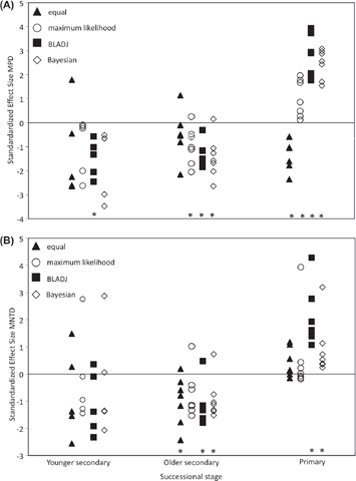

**Figure 3**

Standardized effect size (SES) for mean pair‐wise phylogenetic distance (MPD) of younger secondary, older secondary, and primary New Guinea lowland forest. Points represent SES for 0.25 ha plots under four different methods of phylogenetic branch length estimation as described in Fig. 2. Positive values indicate over‐dispersion whereas negative values indicate clustering. Asterisks indicate overall significance according to two‐tailed t‐tests (p < 0.05).

The sensitivity of these patterns to topological inaccuracy was investigated by examining the significance of MPD and MNTD metrics for each of the most highly clustered and over‐dispersed plots given 100 randomly resolved constraint trees. When time‐calibrated branch lengths were assumed, pattern detection was not affected by uncertainty associated with phylogenetic relationships inferred directly from the rbcL sequences of community members. However, patterns were sensitive in the case of the equal branch length assumption, where significant clustering and over‐dispersion was not detected among all randomly resolved constraint trees. When branch lengths were proportional to maximum likelihood estimates of rbcL divergence, clustering and over‐dispersion were also sensitive to the choice of tree topology.

## Discussion

### Interpreting community phylogenetic patterns

By contrast, primary forest over‐dispersion could be explained in a number of ways. Closely related trees with similar traits might be locally excluded by competition or distantly related species with convergent traits may be filtered into the same environment (Cavender‐Bares et al. 2009, Cornwell and Ackerly 2009). Alternatively, density‐dependent trophic interactions (Gilbert and Webb 2007, Comita et al. 2010) or mutualism and facilitation (Valiente‐Banuet and Verdu 2007, Sargent and Ackerly 2008) could influence the pattern.

Non‐random patterns of tree species co‐occurrence in tropical forests are well‐documented (Webb 2000, Kembel and Hubbell 2006, Kress et al. 2009, Kraft and Ackerly 2010, Letcher 2010). In Borneo, an overall pattern of phylogenetic clustering was detected using a community phylogeny with equal branch lengths (Webb 2000). That habitat associations were stronger for adult trees than seedlings was interpreted as evidence of environmental filtering (Webb and Peart 2000). A recent application of the branch length adjustment algorithm found, to the contrary, that coexisting tree species in Costa Rican secondary forests were more distantly related than expected by chance (Letcher 2010). Overall differences between the New Guinean and Costa Rican patterns may be attributed to several factors. First, the strength and direction of the Costa Rican pattern differed among diameter size‐classes in each successional stage such that the smallest trees (0.5–5.0 cm) of the youngest forest (10–15 yr old) were over‐dispersed whereas trees ≥ 10 cm dbh were phylogenetically clustered. We did not measure trees < 5 cm dbh so the New Guinea pattern is in fact consistent with Costa Rican findings for secondary forest trees of comparable size. Another consideration is that, in Costa Rica, forests had colonized abandoned pasture compared to lightly cultivated subsistence agricultural plots in New Guinea. The higher intensity of disturbance in Costa Rica might also have altered the successional trajectory of this site (Chazdon 2003).

In French Guiana, phylogenetic diversity differed between the seedling layer and the canopy layer (Gonzalez et al. 2010). That the canopy harbored more species and greater phylogenetic diversity than the understory was interpreted as evidence of recruitment into the canopy of multiple seedling cohorts during succession. Our comparison of different successional stages also supports this interpretation where species richness and mean phylogenetic distance increased with forest age. The hypothesis that recruitment during the later phases of succession favors more phylogenetically distant taxa than during early succession possibly due to density‐dependent mortality (Comita et al. 2010) deserves further investigation.

### Phylogenetic assumptions

The interpretation of community phylogenetic patterns depends on assumptions about the relatedness of community members (tree topology) and the extent of temporal divergence or trait divergence among co‐occurring species (branch lengths). For example, Kembel and Hubbell (2006) inferred phylogenetic clustering in Panamanian plateau forest and over‐dispersion in swamp and slope habitats under phylomatic assumptions (Webb et al. 2008) whereas Kress et al. (2009) detected the opposite pattern using DNA sequences. It is necessary to consider differences among various assumptions if meaningful inferences about ecological process are to be gained.

Equating branch lengths assumes that anagensis (evolutionary change along branches) is highly correlated with cladogenesis (speciation). However, the evolution of traits affecting community membership may be decoupled from speciation in which case additional information on evolutionary rates is desirable. Assuming equal branch lengths will also tend to overestimate phylogenetic distance between close relatives and underestimate the divergence of distantly related species in ecological community samples that are highly heterogeneous from a phylogenetic standpoint. The pattern of primary forest clustering detected under the equal branch assumption appears to be an artifact of underestimating the divergence of distantly related community members. Our results further suggest that the equal branch length assumption generally has lower statistical power to detect deviations from null models than time‐calibrated assumptions.

DNA sequences or barcodes such as rbcL provide estimates of anagensis (numbers of substitutions per site) that find ecological interpretation if rates of molecular evolution are assumed to be correlated with morphological trait evolution. Although this assumption is generally supported for particular clades (Omland 1997) local and regional communities are taxonomically heterogeneous and there is potential for biased estimates of trait evolution in communities given the possibility for erroneous inferences to be drawn from incomplete taxon samples (Zwickl and Hillis 2002). More work is needed to assess whether time‐calibrated and relaxed molecular clock methods of branch length estimation might improve accuracy in this respect. In either case, divergence times are assumed to correlate with the phenotypic dissimilarity of lineages arising from their independent evolution under models of Brownian motion. Our results suggest that phylogenetic patterns in New Guinea lowland rain forest tree communities are robust to branch length assumptions so long as divergence is calibrated with respect to time, either by branch length adjustment (BLADJ) or a relaxed molecular clock (Fig. 3).

Findings from New Guinea are consistent with Kress et al. (2009) in demonstrating that DNA barcodes improve the resolution of community phylogeny beyond phylomatic. Whether the detection of phylogenetic pattern is enhanced by such improvement is a separate question that we investigated by comparing our results to randomly resolved constraint trees. Only when branch lengths were assumed to be equal or directly proportional to DNA sequence divergence was the detection of clustering and over‐dispersion sensitive to uncertainty about phylogenetic relationships among community members. Calibrating divergence with respect to time, either by branch length adjustment (BLADJ) or a relaxed molecular clock, may also reduce the chance of type II error in analyses of community phylogenetic structure.

We favor the inference of community phylogeny from a combination of current systematic knowledge with DNA sequences from community members. This approach minimizes inaccuracy associated with phylogenetic inference from incomplete taxon samples (Zwickl and Hillis 2002) while maximizing topological resolution (Uriarte et al. 2010) and adding power to detect community phylogenetic patterns with relaxed molecular clock branch length assumptions. Although patterns inferred under these conditions are among the most likely to be robust, it is necessary to bear in mind that they also depend to some extent on the spatial scale under investigation (Cavender‐Bares et al. 2006, Swenson and Enquist 2007) and the relative size of samples to the regional species pool (Kraft et al. 2007). In any event, empirical results from New Guinea are consistent with recent simulations (Swenson 2009) suggesting that topological uncertainty may not strongly affect the detection of community phylogenetic patterns.

## Conclusions

Community phylogenetic patterns in New Guinea lowland rain forest shift from clustering to over‐dispersion during the course of ecological succession. Comparisons to null models indicate that the change is not simply explained by the overall accumulation of phylogenetic diversity as forests grow older but ecological mechanisms favoring the co‐existence of distantly related taxa. Findings from 0.25 ha plots are consistent with the hypothesis that relatively homo genous conditions in early succession favor the coexistence of related species, which happen to share functional traits associated with success in this environment. The pattern of over‐dispersion apparent in primary forests is consistent with explanations such as environmental filtering of convergent lineages or the competitive exclusion of relatives characterized by trait conservatism. If close relatives with conserved traits share specialized enemies such as pests and pathogens (Wills et al. 2006), then perhaps trophic interactions could mediate local competition (Gilbert and Webb 2007, Comita et al. 2010). On the other hand, convergent lineages might engage in mutualisms, and such facilitation could produce the same pattern (Valiente‐Banuet and Verdu 2007, Sargent and Ackerly 2008).

The overall increase in phylogenetic diversity of primary forest compared to secondary forest may reflect increased time for colonization following disturbance or, alternatively, greater environmental heterogeneity that could facilitate species co‐existence. Examining the phylogenetic distribution of plant functional traits related to survival, reproduction, and dispersal (Kembel 2009) in the context of forest succession could further refine mechanistic hypotheses on species coexistence (Kraft and Ackerly 2010, Uriarte et al. 2010) and growth‐mortality trade‐offs accounting for life history differences among primary and secondary forest tree species (Wright et al. 2010). We hope that such investigations may inform the design of experiments to directly investigate ecological processes affecting community phylogenetic patterns (Cavender‐Bares et al. 2009).

## Acknowledgements

We thank Jeannine Cavender‐Bares and Rebecca Montgomery for comments and guidance. Steve Kembel, Jessica Savage, Cam Webb, Jonathan Eastman, Nathan Swenson, and Eric Lind for advice and assistance with analyses. Annika Moe for comments that improved the manuscript. Vojtech Novotny and staff at the New Guinea Binatang Research Center particularly Gibson Sosanika and Kenneth Molem. For assistance with data management and specimen curation we thank Ross Bernard, Rosanne Healy, and Erin Treiber. Billy Bau and Kipiro Damas (PNG Forest Research Inst.) for help with specimen identifications and fieldwork. Wanang village assistants for help with fieldwork. This work was supported by a US National Science Foundation grant (DEB‐0515678), the Consortium for the Barcode of Life, the Arnold Arboretum (Deland Award for student research), the Society of Systematic Biologists (award for Graduate Student Research), the Systematics Association (Systematics Research Fund), and Univ. of Minnesota (Dept of Plant Biology, Dept of Ecology, Evolution, and Behavior, Office of International Programs, Graduate School).

## References

Supplementary material (Appendix E7181 at <www.oikosoffice.lu.se/appendix>). Appendix 1.

September 2012

Pages 821-830

### Details

  © 2011 The Authors